# Prosta_analiza_danych

```python
import numpy as np
import pandas as pd
import matplotlib.pyplot as plt
import seaborn as sns
```

```python
import warnings
warnings.filterwarnings('ignore')
```

```python
airquality = pd.read_excel('AirQualityUCI.xlsx')
airquality
```

|  | Date | Time | CO(GT) | PT08.S1(CO) | NMHC(GT) | C6H6(GT) | PT08.S2(NMHC) | NOx(GT) | PT08.S3(NOx) | NO2(GT) | PT08.S4(NO2) | PT08.S5(O3) | T | RH | AH |
| --- | --- | --- | --- | --- | --- | --- | --- | --- | --- | --- | --- | --- | --- | --- | --- |
| 0 | 2004-03-10 | 18:00:00 | 2.6 | 1360.00 | 150 | 11.881723 | 1045.50 | 166.0 | 1056.25 | 113.0 | 1692.00 | 1267.50 | 13.600 | 48.875001 | 0.757754 |
| 1 | 2004-03-10 | 19:00:00 | 2.0 | 1292.25 | 112 | 9.397165 | 954.75 | 103.0 | 1173.75 | 92.0 | 1558.75 | 972.25 | 13.300 | 47.700000 | 0.725487 |
| 2 | 2004-03-10 | 20:00:00 | 2.2 | 1402.00 | 88 | 8.997817 | 939.25 | 131.0 | 1140.00 | 114.0 | 1554.50 | 1074.00 | 11.900 | 53.975000 | 0.750239 |
| 3 | 2004-03-10 | 21:00:00 | 2.2 | 1375.50 | 80 | 9.228796 | 948.25 | 172.0 | 1092.00 | 122.0 | 1583.75 | 1203.25 | 11.000 | 60.000000 | 0.786713 |
| 4 | 2004-03-10 | 22:00:00 | 1.6 | 1272.25 | 51 | 6.518224 | 835.50 | 131.0 | 1205.00 | 116.0 | 1490.00 | 1110.00 | 11.150 | 59.575001 | 0.788794 |
| ... | ... | ... | ... | ... | ... | ... | ... | ... | ... | ... | ... | ... | ... | ... | ... |
| 9352 | 2005-04-04 | 10:00:00 | 3.1 | 1314.25 | -200 | 13.529605 | 1101.25 | 471.7 | 538.50 | 189.8 | 1374.25 | 1728.50 | 21.850 | 29.250000 | 0.756824 |
| 9353 | 2005-04-04 | 11:00:00 | 2.4 | 1162.50 | -200 | 11.355157 | 1027.00 | 353.3 | 603.75 | 179.2 | 1263.50 | 1269.00 | 24.325 | 23.725000 | 0.711864 |
| 9354 | 2005-04-04 | 12:00:00 | 2.4 | 1142.00 | -200 | 12.374538 | 1062.50 | 293.0 | 603.25 | 174.7 | 1240.75 | 1092.00 | 26.900 | 18.350000 | 0.640649 |
| 9355 | 2005-04-04 | 13:00:00 | 2.1 | 1002.50 | -200 | 9.547187 | 960.50 | 234.5 | 701.50 | 155.7 | 1041.00 | 769.75 | 28.325 | 13.550000 | 0.513866 |
| 9356 | 2005-04-04 | 14:00:00 | 2.2 | 1070.75 | -200 | 11.932060 | 1047.25 | 265.2 | 654.00 | 167.7 | 1128.50 | 816.00 | 28.500 | 13.125000 | 0.502804 |

9357 rows × 15 columns

Wyjaśnienia oznaczeń kolumn

- 0 Data (DD/MM/RRRR)
- 1 Czas (GG.MM.SS)
- 2 Rzeczywiste godzinowe uśrednione stężenie CO w mg/m^3 (analizator odniesienia)
- 3 PT08.S1 (tlenek cyny) godzinowa uśredniona odpowiedź czujnika (nominalnie ukierunkowana na CO)
- 4 Prawdziwe uśrednione godzinowo całkowite stężenie węglowodorów niemetalicznych w mikrog/m^3 (analizator referencyjny)
- 5 Rzeczywiste uśrednione godzinowo stężenie benzenu w mikrog/m^3 (analizator referencyjny)
- 6 PT08.S2 (tytania) uśredniona godzinowa odpowiedź czujnika (nominalnie ukierunkowana na NMHC)
- 7 Rzeczywiste godzinowe uśrednione stężenie NOx w ppb (analizator odniesienia)
- 8 PT08.S3 (tlenek wolframu) godzinowa uśredniona odpowiedź czujnika (nominalnie ukierunkowana na NOx)
- 9 Rzeczywiste godzinowe uśrednione stężenie NO2 w mikrog/m^3 (analizator referencyjny)
- 10 PT08.S4 (tlenek wolframu) godzinowa uśredniona odpowiedź czujnika (nominalnie ukierunkowana na NO2)
- 11 PT08.S5 (tlenek indu) godzinowa uśredniona odpowiedź czujnika (nominalnie ukierunkowane na O3)
- 12 Temperatura w °C
- 13 Wilgotność względna (%)
- 14 AH bezwzględna wilgotność

## Rysuje wykres zmiennej 'RH'

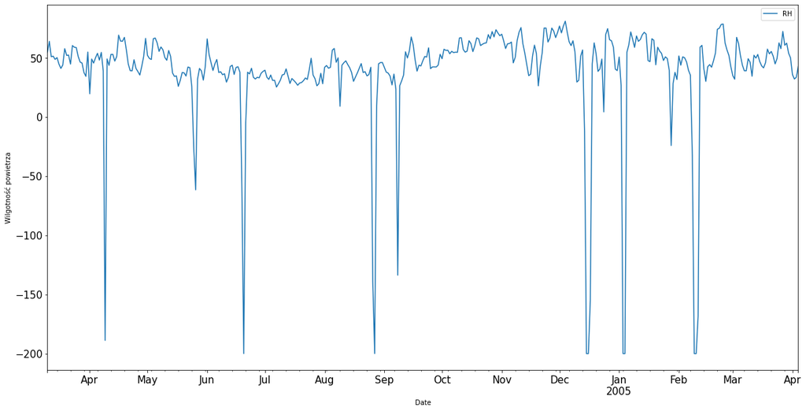

```python
plt.figure(figsize=(20,10))
airquality.groupby('Date')['RH'].mean().plot(x = 'Date',
                                             y='RH',
                                             legend='auto',
                                             ylabel = "Wilgotność powietrza",
                                             fontsize =15)
```

### Sprawdzam jak dużo jest pustych pomiarów.

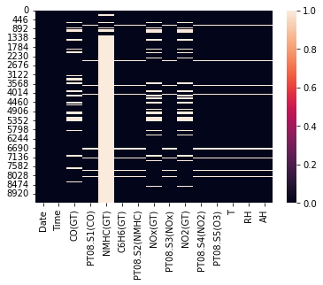

```python
sns.heatmap(airquality==-200 )
```

```python
airquality['NMHC(GT)'].value_counts()
```

```
-200    8443
 66       14
 40        9
 29        9
 88        8
        ...
 422       1
 424       1
 339       1
 445       1
 307       1
Name: NMHC(GT), Length: 430, dtype: int64
```

### 8443 z 9357 obserwacji w kolumnie "NMHC(GT)" jest pusta, tak wiec ta zmienna nie będzie wpływac na badanie w żaden pozytywny sposób.

```python
airquality = airquality.drop('NMHC(GT)',axis=1) # Usunięcie cechy "NMHC(GT)" ze zbioru.
airquality
```

|  | Date | Time | CO(GT) | PT08.S1(CO) | C6H6(GT) | PT08.S2(NMHC) | NOx(GT) | PT08.S3(NOx) | NO2(GT) | PT08.S4(NO2) | PT08.S5(O3) | T | RH | AH |
| --- | --- | --- | --- | --- | --- | --- | --- | --- | --- | --- | --- | --- | --- | --- |
| 0 | 2004-03-10 | 18:00:00 | 2.6 | 1360.00 | 11.881723 | 1045.50 | 166.0 | 1056.25 | 113.0 | 1692.00 | 1267.50 | 13.600 | 48.875001 | 0.757754 |
| 1 | 2004-03-10 | 19:00:00 | 2.0 | 1292.25 | 9.397165 | 954.75 | 103.0 | 1173.75 | 92.0 | 1558.75 | 972.25 | 13.300 | 47.700000 | 0.725487 |
| 2 | 2004-03-10 | 20:00:00 | 2.2 | 1402.00 | 8.997817 | 939.25 | 131.0 | 1140.00 | 114.0 | 1554.50 | 1074.00 | 11.900 | 53.975000 | 0.750239 |
| 3 | 2004-03-10 | 21:00:00 | 2.2 | 1375.50 | 9.228796 | 948.25 | 172.0 | 1092.00 | 122.0 | 1583.75 | 1203.25 | 11.000 | 60.000000 | 0.786713 |
| 4 | 2004-03-10 | 22:00:00 | 1.6 | 1272.25 | 6.518224 | 835.50 | 131.0 | 1205.00 | 116.0 | 1490.00 | 1110.00 | 11.150 | 59.575001 | 0.788794 |
| ... | ... | ... | ... | ... | ... | ... | ... | ... | ... | ... | ... | ... | ... | ... |
| 9352 | 2005-04-04 | 10:00:00 | 3.1 | 1314.25 | 13.529605 | 1101.25 | 471.7 | 538.50 | 189.8 | 1374.25 | 1728.50 | 21.850 | 29.250000 | 0.756824 |
| 9353 | 2005-04-04 | 11:00:00 | 2.4 | 1162.50 | 11.355157 | 1027.00 | 353.3 | 603.75 | 179.2 | 1263.50 | 1269.00 | 24.325 | 23.725000 | 0.711864 |
| 9354 | 2005-04-04 | 12:00:00 | 2.4 | 1142.00 | 12.374538 | 1062.50 | 293.0 | 603.25 | 174.7 | 1240.75 | 1092.00 | 26.900 | 18.350000 | 0.640649 |
| 9355 | 2005-04-04 | 13:00:00 | 2.1 | 1002.50 | 9.547187 | 960.50 | 234.5 | 701.50 | 155.7 | 1041.00 | 769.75 | 28.325 | 13.550000 | 0.513866 |
| 9356 | 2005-04-04 | 14:00:00 | 2.2 | 1070.75 | 11.932060 | 1047.25 | 265.2 | 654.00 | 167.7 | 1128.50 | 816.00 | 28.500 | 13.125000 | 0.502804 |

9357 rows × 14 columns

```python
sns.heatmap(airquality==-200 )
```

[output not shown]

### Liczba pustych wartości które trzeba zastąpić

```python
(airquality==-200).sum()
```

```
Date                0
Time                0
CO(GT)           1683
PT08.S1(CO)       366
C6H6(GT)          366
PT08.S2(NMHC)     366
NOx(GT)          1639
PT08.S3(NOx)      366
NO2(GT)          1642
PT08.S4(NO2)      366
PT08.S5(O3)       366
T                 366
RH                366
AH                366
dtype: int64
```

### Dla każdej cechy wartości pustę zostaną zastąpione medianą tej cechy.

```python
for a in airquality.columns:
    for b in range(len(airquality)):
        if airquality[a][b] == -200:
            airquality[a][b] = airquality[airquality[a]!=-200][a].median()
        else:
            pass
```

```python
airquality
```

|  | Date | Time | CO(GT) | PT08.S1(CO) | C6H6(GT) | PT08.S2(NMHC) | NOx(GT) | PT08.S3(NOx) | NO2(GT) | PT08.S4(NO2) | PT08.S5(O3) | T | RH | AH |
| --- | --- | --- | --- | --- | --- | --- | --- | --- | --- | --- | --- | --- | --- | --- |
| 0 | 2004-03-10 | 18:00:00 | 2.6 | 1360.00 | 11.881723 | 1045.50 | 166.0 | 1056.25 | 113.0 | 1692.00 | 1267.50 | 13.600 | 48.875001 | 0.757754 |
| 1 | 2004-03-10 | 19:00:00 | 2.0 | 1292.25 | 9.397165 | 954.75 | 103.0 | 1173.75 | 92.0 | 1558.75 | 972.25 | 13.300 | 47.700000 | 0.725487 |
| 2 | 2004-03-10 | 20:00:00 | 2.2 | 1402.00 | 8.997817 | 939.25 | 131.0 | 1140.00 | 114.0 | 1554.50 | 1074.00 | 11.900 | 53.975000 | 0.750239 |
| 3 | 2004-03-10 | 21:00:00 | 2.2 | 1375.50 | 9.228796 | 948.25 | 172.0 | 1092.00 | 122.0 | 1583.75 | 1203.25 | 11.000 | 60.000000 | 0.786713 |
| 4 | 2004-03-10 | 22:00:00 | 1.6 | 1272.25 | 6.518224 | 835.50 | 131.0 | 1205.00 | 116.0 | 1490.00 | 1110.00 | 11.150 | 59.575001 | 0.788794 |
| ... | ... | ... | ... | ... | ... | ... | ... | ... | ... | ... | ... | ... | ... | ... |
| 9352 | 2005-04-04 | 10:00:00 | 3.1 | 1314.25 | 13.529605 | 1101.25 | 471.7 | 538.50 | 189.8 | 1374.25 | 1728.50 | 21.850 | 29.250000 | 0.756824 |
| 9353 | 2005-04-04 | 11:00:00 | 2.4 | 1162.50 | 11.355157 | 1027.00 | 353.3 | 603.75 | 179.2 | 1263.50 | 1269.00 | 24.325 | 23.725000 | 0.711864 |
| 9354 | 2005-04-04 | 12:00:00 | 2.4 | 1142.00 | 12.374538 | 1062.50 | 293.0 | 603.25 | 174.7 | 1240.75 | 1092.00 | 26.900 | 18.350000 | 0.640649 |
| 9355 | 2005-04-04 | 13:00:00 | 2.1 | 1002.50 | 9.547187 | 960.50 | 234.5 | 701.50 | 155.7 | 1041.00 | 769.75 | 28.325 | 13.550000 | 0.513866 |
| 9356 | 2005-04-04 | 14:00:00 | 2.2 | 1070.75 | 11.932060 | 1047.25 | 265.2 | 654.00 | 167.7 | 1128.50 | 816.00 | 28.500 | 13.125000 | 0.502804 |

9357 rows × 14 columns

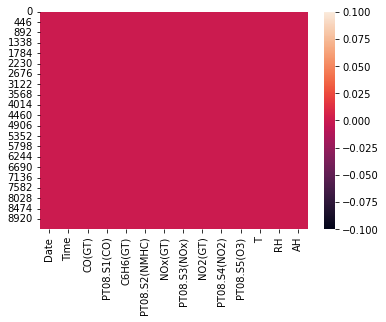

```python
sns.heatmap(airquality==-200 )
```

Wszystkie puste obserwacje zostały zastąpoone medianą.

### Narysujmy ponownie wykres wilgotności powietrza

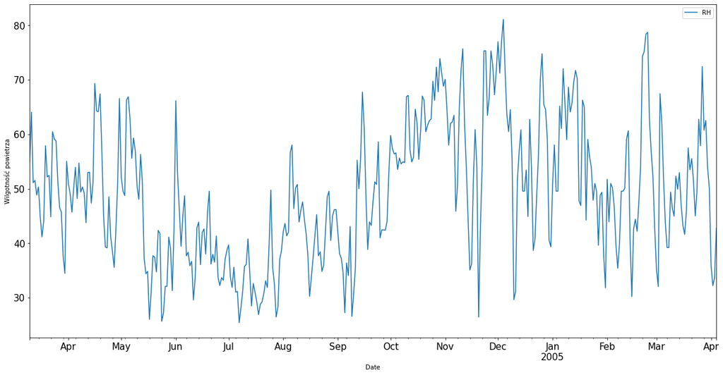

```python
plt.figure(figsize=(20,10))
airquality.groupby('Date')['RH'].mean().plot(x = 'Date',
                                             y='RH',
                                             legend='auto',
                                             ylabel = "Wilgotność powietrza",
                                             fontsize =15)
```

### Wykres prezentuje się zupełnie inaczej.

### Uzupełnijmy braki w danych używając do tego metody najbliższych sąsiadów. Porównajmy medoty, która działa efektywniej.

```python
from sklearn.impute import KNNImputer
```

### Zamienińmy zmienne -200 na NaN

```python
airqualityKNN = pd.read_excel('AirQualityUCI.xlsx')
airqualityKNN = airqualityKNN.drop('NMHC(GT)',axis=1)
```

### Zamiana pustych danych(-200) na NaN

```python
for a in airqualityKNN.columns:
    for b in range(len(airqualityKNN)):
        if airqualityKNN[a][b] == -200:
            airqualityKNN[a][b] = np.NaN
        else:
            pass
```

```python
sns.heatmap(airqualityKNN.isna())
```

[output not shown]

### Zastąpienie pustych wartości "NaN" na przewidziane przez metodę KNN

```python
imputer = KNNImputer(n_neighbors=5)

airqualityKNNTransform = imputer.fit_transform(airqualityKNN.iloc[:, 2:])

airqualityKNN[airqualityKNN.iloc[:, 2:].columns]= airqualityKNNTransform

airqualityKNN
```

|  | Date | Time | CO(GT) | PT08.S1(CO) | C6H6(GT) | PT08.S2(NMHC) | NOx(GT) | PT08.S3(NOx) | NO2(GT) | PT08.S4(NO2) | PT08.S5(O3) | T | RH | AH |
| --- | --- | --- | --- | --- | --- | --- | --- | --- | --- | --- | --- | --- | --- | --- |
| 0 | 2004-03-10 | 18:00:00 | 2.6 | 1360.00 | 11.881723 | 1045.50 | 166.0 | 1056.25 | 113.0 | 1692.00 | 1267.50 | 13.600 | 48.875001 | 0.757754 |
| 1 | 2004-03-10 | 19:00:00 | 2.0 | 1292.25 | 9.397165 | 954.75 | 103.0 | 1173.75 | 92.0 | 1558.75 | 972.25 | 13.300 | 47.700000 | 0.725487 |
| 2 | 2004-03-10 | 20:00:00 | 2.2 | 1402.00 | 8.997817 | 939.25 | 131.0 | 1140.00 | 114.0 | 1554.50 | 1074.00 | 11.900 | 53.975000 | 0.750239 |
| 3 | 2004-03-10 | 21:00:00 | 2.2 | 1375.50 | 9.228796 | 948.25 | 172.0 | 1092.00 | 122.0 | 1583.75 | 1203.25 | 11.000 | 60.000000 | 0.786713 |
| 4 | 2004-03-10 | 22:00:00 | 1.6 | 1272.25 | 6.518224 | 835.50 | 131.0 | 1205.00 | 116.0 | 1490.00 | 1110.00 | 11.150 | 59.575001 | 0.788794 |
| ... | ... | ... | ... | ... | ... | ... | ... | ... | ... | ... | ... | ... | ... | ... |
| 9352 | 2005-04-04 | 10:00:00 | 3.1 | 1314.25 | 13.529605 | 1101.25 | 471.7 | 538.50 | 189.8 | 1374.25 | 1728.50 | 21.850 | 29.250000 | 0.756824 |
| 9353 | 2005-04-04 | 11:00:00 | 2.4 | 1162.50 | 11.355157 | 1027.00 | 353.3 | 603.75 | 179.2 | 1263.50 | 1269.00 | 24.325 | 23.725000 | 0.711864 |
| 9354 | 2005-04-04 | 12:00:00 | 2.4 | 1142.00 | 12.374538 | 1062.50 | 293.0 | 603.25 | 174.7 | 1240.75 | 1092.00 | 26.900 | 18.350000 | 0.640649 |
| 9355 | 2005-04-04 | 13:00:00 | 2.1 | 1002.50 | 9.547187 | 960.50 | 234.5 | 701.50 | 155.7 | 1041.00 | 769.75 | 28.325 | 13.550000 | 0.513866 |
| 9356 | 2005-04-04 | 14:00:00 | 2.2 | 1070.75 | 11.932060 | 1047.25 | 265.2 | 654.00 | 167.7 | 1128.50 | 816.00 | 28.500 | 13.125000 | 0.502804 |

9357 rows × 14 columns

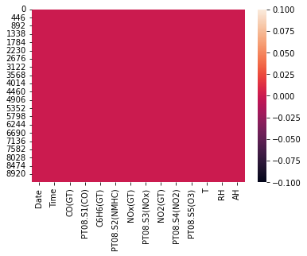

```python
sns.heatmap(airqualityKNN.isna())
```

Brak pustych obserwacji

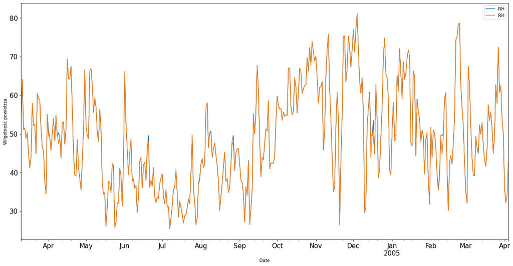

```python
plt.figure(figsize=(20,10))
airquality.groupby('Date')['RH'].mean().plot(x = 'Date',
                                             y='RH',
                                             legend="auto",
                                             ylabel = "Wilgotność powietrza",
                                             fontsize =15)
airqualityKNN.groupby('Date')['RH'].mean().plot(x = 'Date',
                                             y='RH',
                                             legend="auto",
                                             ylabel = "Wilgotność powietrza",
                                             fontsize =15)
```

### Widzimy lekkie rożnice. Sprawdźmy wykresy watości z wiekszymi brakami.

##### Niebieski kolor należy do uzupełnienia medianą, żółty do zastępienia metodą KNN

#### Spójrzmy na cechę z wiekszą liczbą braków

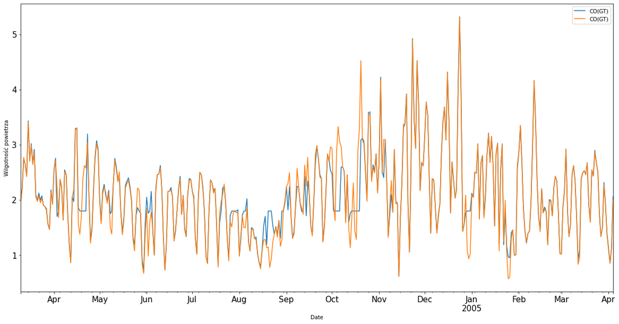

```python
plt.figure(figsize=(20,10))
airquality.groupby('Date')['CO(GT)'].mean().plot(x = 'Date',
                                             y='CO(GT)',
                                             legend= 'CO(GT) uzupełnione metodą KNN',
                                             ylabel = "Wilgotność powietrza",
                                             fontsize =15)

airqualityKNN.groupby('Date')['CO(GT)'].mean().plot(x = 'Date',
                                             y='CO(GT)',
                                             legend='auto',
                                             ylabel = "Wilgotność powietrza",
                                             fontsize =15)
```

Widać znaczące różnice pomiedzy wypełniniami, dlatego trzeba z rozwagą zasępować braki.

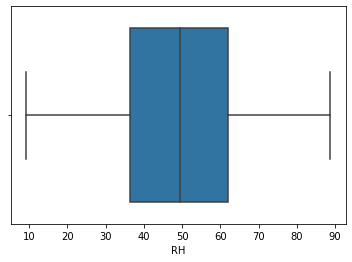

```python
sns.boxplot(airqualityKNN['RH'])
```

### Wykres po wypełnieniu metodą KNN

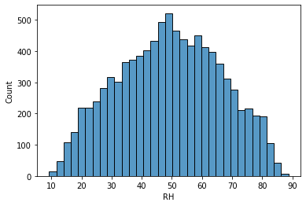

```python
sns.histplot(airqualityKNN['RH'])
```

### Wykres po wypełnieniu Medianą

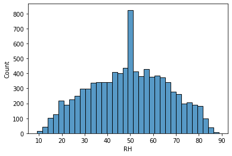

```python
sns.histplot(airquality['RH'])
```

Patrząc na te dwa histogramy, widzimy różnice i wyższość techniki KNN wypełniania pustych pól, nad używaniem mediany. \ Przy niewielkiej ilosci brakujących danych nie stanowi to problemu, lecz jak 3 kolumny miały prawie 20% danych pustych,\ to wypełnienie ich medianą może spowodować nieporawidłowy wynik badania.

```python
import sklearn
from sklearn.cluster import DBSCAN
from collections import Counter
```

```python
model = DBSCAN(eps= 0.8, min_samples=2).fit(airqualityKNN.iloc[:,2:])
outliers_df = pd.DataFrame(airqualityKNN.iloc[:,2:])
model.labels_
```

```
array([-1, -1, -1, ..., -1, -1, -1], dtype=int64)
```

```python
print(Counter(model.labels_))
print(outliers_df[model.labels_!=-1])
```

```
Counter({-1: 9324, 0: 31, 1: 2})
       CO(GT)  PT08.S1(CO)   C6H6(GT)  PT08.S2(NMHC)     NOx(GT)  \
1825  2.15275  1099.707856  10.082993     939.029205  246.881252
1826  2.15275  1099.707856  10.082993     939.029205  246.881252
1827  2.15275  1099.707856  10.082993     939.029205  246.881252
1828  2.15275  1099.707856  10.082993     939.029205  246.881252
1829  2.15275  1099.707856  10.082993     939.029205  246.881252
1830  2.15275  1099.707856  10.082993     939.029205  246.881252
1831  2.15275  1099.707856  10.082993     939.029205  246.881252
1832  2.15275  1099.707856  10.082993     939.029205  246.881252
1833  2.15275  1099.707856  10.082993     939.029205  246.881252
1834  2.15275  1099.707856  10.082993     939.029205  246.881252
1835  2.15275  1099.707856  10.082993     939.029205  246.881252
1836  2.15275  1099.707856  10.082993     939.029205  246.881252
1837  2.15275  1099.707856  10.082993     939.029205  246.881252
```

[output cut: 90 more lines]

Widzimy ze pomiary nie różnią się od siebie. Są pomiary następujące jedne po drugich i nie różnią się od siebie, ale mamy pomiar 705 i 1825 z takimisamymi wartościami we wszystkich cechach oprócz cechy "CO(GT)", która jest zmienna. Nie możemy wziąc takich obserwacji pod uwagę, ponieważ są to obserwacje spowodowane błędami urządzenia. Nie ma możliwości, aby w naturze wystąpiło takie podobieństwo wysępujące jedno po drugim. A co mówić w dużych odstępach czasu.

### Przyjrzyjmy się pomiarom sprzed anomali pomiarowej.

```python
airqualityKNN.iloc[1820:1842,:]
```

|  | Date | Time | CO(GT) | PT08.S1(CO) | C6H6(GT) | PT08.S2(NMHC) | NOx(GT) | PT08.S3(NOx) | NO2(GT) | PT08.S4(NO2) | PT08.S5(O3) | T | RH | AH |
| --- | --- | --- | --- | --- | --- | --- | --- | --- | --- | --- | --- | --- | --- | --- |
| 1820 | 2004-05-25 | 14:00:00 | 2.40000 | 1162.250000 | 18.450939 | 1252.500000 | 173.000000 | 795.750000 | 138.000000 | 1594.500000 | 1248.250000 | 32.599999 | 9.30000 | 0.449949 |
| 1821 | 2004-05-25 | 15:00:00 | 2.10000 | 1058.750000 | 12.587302 | 1069.750000 | 234.000000 | 925.000000 | 125.400000 | 1401.000000 | 976.250000 | 32.599999 | 9.22500 | 0.446320 |
| 1822 | 2004-05-25 | 16:00:00 | 1.96000 | 1082.500000 | 12.040229 | 1051.000000 | 253.000000 | 938.500000 | 127.400000 | 1389.750000 | 897.750000 | 32.349999 | 9.95000 | 0.474678 |
| 1823 | 2004-05-25 | 17:00:00 | 2.58000 | 1149.500000 | 15.379958 | 1160.500000 | 327.000000 | 866.500000 | 149.000000 | 1512.000000 | 1038.250000 | 32.050000 | 10.65000 | 0.499560 |
| 1824 | 2004-05-25 | 18:00:00 | 3.48000 | 1321.000000 | 24.877672 | 1426.000000 | 219.600000 | 720.000000 | 169.000000 | 1859.000000 | 1395.000000 | 29.700001 | 12.20000 | 0.500744 |
| 1825 | 2004-05-25 | 19:00:00 | 2.15275 | 1099.707856 | 10.082993 | 939.029205 | 246.881252 | 835.370973 | 113.075515 | 1456.143486 | 1022.780725 | 18.316054 | 49.23236 | 1.025530 |
| 1826 | 2004-05-25 | 20:00:00 | 2.15275 | 1099.707856 | 10.082993 | 939.029205 | 246.881252 | 835.370973 | 113.075515 | 1456.143486 | 1022.780725 | 18.316054 | 49.23236 | 1.025530 |
| 1827 | 2004-05-25 | 21:00:00 | 2.15275 | 1099.707856 | 10.082993 | 939.029205 | 246.881252 | 835.370973 | 113.075515 | 1456.143486 | 1022.780725 | 18.316054 | 49.23236 | 1.025530 |
| 1828 | 2004-05-25 | 22:00:00 | 2.15275 | 1099.707856 | 10.082993 | 939.029205 | 246.881252 | 835.370973 | 113.075515 | 1456.143486 | 1022.780725 | 18.316054 | 49.23236 | 1.025530 |
| 1829 | 2004-05-25 | 23:00:00 | 2.15275 | 1099.707856 | 10.082993 | 939.029205 | 246.881252 | 835.370973 | 113.075515 | 1456.143486 | 1022.780725 | 18.316054 | 49.23236 | 1.025530 |
| 1830 | 2004-05-26 | 00:00:00 | 2.15275 | 1099.707856 | 10.082993 | 939.029205 | 246.881252 | 835.370973 | 113.075515 | 1456.143486 | 1022.780725 | 18.316054 | 49.23236 | 1.025530 |
| 1831 | 2004-05-26 | 01:00:00 | 2.15275 | 1099.707856 | 10.082993 | 939.029205 | 246.881252 | 835.370973 | 113.075515 | 1456.143486 | 1022.780725 | 18.316054 | 49.23236 | 1.025530 |
| 1832 | 2004-05-26 | 02:00:00 | 2.15275 | 1099.707856 | 10.082993 | 939.029205 | 246.881252 | 835.370973 | 113.075515 | 1456.143486 | 1022.780725 | 18.316054 | 49.23236 | 1.025530 |
| 1833 | 2004-05-26 | 03:00:00 | 2.15275 | 1099.707856 | 10.082993 | 939.029205 | 246.881252 | 835.370973 | 113.075515 | 1456.143486 | 1022.780725 | 18.316054 | 49.23236 | 1.025530 |
| 1834 | 2004-05-26 | 04:00:00 | 2.15275 | 1099.707856 | 10.082993 | 939.029205 | 246.881252 | 835.370973 | 113.075515 | 1456.143486 | 1022.780725 | 18.316054 | 49.23236 | 1.025530 |
| 1835 | 2004-05-26 | 05:00:00 | 2.15275 | 1099.707856 | 10.082993 | 939.029205 | 246.881252 | 835.370973 | 113.075515 | 1456.143486 | 1022.780725 | 18.316054 | 49.23236 | 1.025530 |
| 1836 | 2004-05-26 | 06:00:00 | 2.15275 | 1099.707856 | 10.082993 | 939.029205 | 246.881252 | 835.370973 | 113.075515 | 1456.143486 | 1022.780725 | 18.316054 | 49.23236 | 1.025530 |
| 1837 | 2004-05-26 | 07:00:00 | 2.15275 | 1099.707856 | 10.082993 | 939.029205 | 246.881252 | 835.370973 | 113.075515 | 1456.143486 | 1022.780725 | 18.316054 | 49.23236 | 1.025530 |
| 1838 | 2004-05-26 | 08:00:00 | 2.15275 | 1099.707856 | 10.082993 | 939.029205 | 246.881252 | 835.370973 | 113.075515 | 1456.143486 | 1022.780725 | 18.316054 | 49.23236 | 1.025530 |
| 1839 | 2004-05-26 | 09:00:00 | 4.00000 | 1302.750000 | 40.223805 | 1775.500000 | 785.200000 | 945.500000 | 161.400000 | 1466.750000 | 1607.750000 | 20.350000 | 35.72500 | 0.843977 |
| 1840 | 2004-05-26 | 10:00:00 | 2.20000 | 1137.250000 | 14.925719 | 1146.250000 | 188.000000 | 1144.000000 | 136.000000 | 1392.250000 | 1326.750000 | 26.100000 | 23.82500 | 0.793775 |
| 1841 | 2004-05-26 | 11:00:00 | 1.80000 | 1139.250000 | 13.773525 | 1109.250000 | 159.000000 | 1117.750000 | 135.000000 | 1435.750000 | 1291.500000 | 28.775000 | 21.05000 | 0.819289 |

### Muszę sprawdzić czy te elementy odstające nie powstały z powodu uzupełniania

```python
airqualitytest = pd.read_excel('AirQualityUCI.xlsx')
airqualitytest = airqualitytest.drop('NMHC(GT)',axis=1)
```

```python
airqualitytest.iloc[1820:1842,:]
```

|  | Date | Time | CO(GT) | PT08.S1(CO) | C6H6(GT) | PT08.S2(NMHC) | NOx(GT) | PT08.S3(NOx) | NO2(GT) | PT08.S4(NO2) | PT08.S5(O3) | T | RH | AH |
| --- | --- | --- | --- | --- | --- | --- | --- | --- | --- | --- | --- | --- | --- | --- |
| 1820 | 2004-05-25 | 14:00:00 | 2.4 | 1162.25 | 18.450939 | 1252.50 | 173.0 | 795.75 | 138.0 | 1594.50 | 1248.25 | 32.599999 | 9.300 | 0.449949 |
| 1821 | 2004-05-25 | 15:00:00 | -200.0 | 1058.75 | 12.587302 | 1069.75 | -200.0 | 925.00 | -200.0 | 1401.00 | 976.25 | 32.599999 | 9.225 | 0.446320 |
| 1822 | 2004-05-25 | 16:00:00 | -200.0 | 1082.50 | 12.040229 | 1051.00 | -200.0 | 938.50 | -200.0 | 1389.75 | 897.75 | 32.349999 | 9.950 | 0.474678 |
| 1823 | 2004-05-25 | 17:00:00 | -200.0 | 1149.50 | 15.379958 | 1160.50 | -200.0 | 866.50 | -200.0 | 1512.00 | 1038.25 | 32.050000 | 10.650 | 0.499560 |
| 1824 | 2004-05-25 | 18:00:00 | -200.0 | 1321.00 | 24.877672 | 1426.00 | -200.0 | 720.00 | -200.0 | 1859.00 | 1395.00 | 29.700001 | 12.200 | 0.500744 |
| 1825 | 2004-05-25 | 19:00:00 | -200.0 | -200.00 | -200.000000 | -200.00 | -200.0 | -200.00 | -200.0 | -200.00 | -200.00 | -200.000000 | -200.000 | -200.000000 |
| 1826 | 2004-05-25 | 20:00:00 | -200.0 | -200.00 | -200.000000 | -200.00 | -200.0 | -200.00 | -200.0 | -200.00 | -200.00 | -200.000000 | -200.000 | -200.000000 |
| 1827 | 2004-05-25 | 21:00:00 | -200.0 | -200.00 | -200.000000 | -200.00 | -200.0 | -200.00 | -200.0 | -200.00 | -200.00 | -200.000000 | -200.000 | -200.000000 |
| 1828 | 2004-05-25 | 22:00:00 | -200.0 | -200.00 | -200.000000 | -200.00 | -200.0 | -200.00 | -200.0 | -200.00 | -200.00 | -200.000000 | -200.000 | -200.000000 |
| 1829 | 2004-05-25 | 23:00:00 | -200.0 | -200.00 | -200.000000 | -200.00 | -200.0 | -200.00 | -200.0 | -200.00 | -200.00 | -200.000000 | -200.000 | -200.000000 |
| 1830 | 2004-05-26 | 00:00:00 | -200.0 | -200.00 | -200.000000 | -200.00 | -200.0 | -200.00 | -200.0 | -200.00 | -200.00 | -200.000000 | -200.000 | -200.000000 |
| 1831 | 2004-05-26 | 01:00:00 | -200.0 | -200.00 | -200.000000 | -200.00 | -200.0 | -200.00 | -200.0 | -200.00 | -200.00 | -200.000000 | -200.000 | -200.000000 |
| 1832 | 2004-05-26 | 02:00:00 | -200.0 | -200.00 | -200.000000 | -200.00 | -200.0 | -200.00 | -200.0 | -200.00 | -200.00 | -200.000000 | -200.000 | -200.000000 |
| 1833 | 2004-05-26 | 03:00:00 | -200.0 | -200.00 | -200.000000 | -200.00 | -200.0 | -200.00 | -200.0 | -200.00 | -200.00 | -200.000000 | -200.000 | -200.000000 |
| 1834 | 2004-05-26 | 04:00:00 | -200.0 | -200.00 | -200.000000 | -200.00 | -200.0 | -200.00 | -200.0 | -200.00 | -200.00 | -200.000000 | -200.000 | -200.000000 |
| 1835 | 2004-05-26 | 05:00:00 | -200.0 | -200.00 | -200.000000 | -200.00 | -200.0 | -200.00 | -200.0 | -200.00 | -200.00 | -200.000000 | -200.000 | -200.000000 |
| 1836 | 2004-05-26 | 06:00:00 | -200.0 | -200.00 | -200.000000 | -200.00 | -200.0 | -200.00 | -200.0 | -200.00 | -200.00 | -200.000000 | -200.000 | -200.000000 |
| 1837 | 2004-05-26 | 07:00:00 | -200.0 | -200.00 | -200.000000 | -200.00 | -200.0 | -200.00 | -200.0 | -200.00 | -200.00 | -200.000000 | -200.000 | -200.000000 |
| 1838 | 2004-05-26 | 08:00:00 | -200.0 | -200.00 | -200.000000 | -200.00 | -200.0 | -200.00 | -200.0 | -200.00 | -200.00 | -200.000000 | -200.000 | -200.000000 |
| 1839 | 2004-05-26 | 09:00:00 | 4.0 | 1302.75 | 40.223805 | 1775.50 | -200.0 | 945.50 | -200.0 | 1466.75 | 1607.75 | 20.350000 | 35.725 | 0.843977 |
| 1840 | 2004-05-26 | 10:00:00 | 2.2 | 1137.25 | 14.925719 | 1146.25 | 188.0 | 1144.00 | 136.0 | 1392.25 | 1326.75 | 26.100000 | 23.825 | 0.793775 |
| 1841 | 2004-05-26 | 11:00:00 | 1.8 | 1139.25 | 13.773525 | 1109.25 | 159.0 | 1117.75 | 135.0 | 1435.75 | 1291.50 | 28.775000 | 21.050 | 0.819289 |

Widzimy, że powodem anomali jest to, że nie zostały usunięte obserwacje z wieloma brakami. To spowodowało błędne wypełnienia.

```python
sns.heatmap(airqualitytest==-200)
```

[output not shown]

```python
for a in airqualitytest.columns:
    for b in range(len(airqualitytest)):
        if airqualitytest[a][b] == -200:
            airqualitytest[a][b] = np.NaN
        else:
            pass
```

```python
airqualitytest.dropna(thresh=10).count()
```

```
Date             8991
Time             8991
CO(GT)           7344
PT08.S1(CO)      8991
C6H6(GT)         8991
PT08.S2(NMHC)    8991
NOx(GT)          7396
PT08.S3(NOx)     8991
NO2(GT)          7393
PT08.S4(NO2)     8991
PT08.S5(O3)      8991
T                8991
RH               8991
AH               8991
dtype: int64
```

### Usuwamy obserwacje które mają 9 cech bez braków.

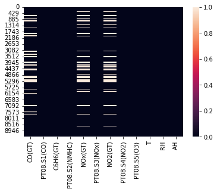

```python
sns.heatmap(airqualitytest.iloc[:,2:].dropna(thresh=9).isna())
```

```python
airqualitytest.iloc[:,2:].dropna(thresh=8).count()
```

```
CO(GT)           7344
PT08.S1(CO)      8991
C6H6(GT)         8991
PT08.S2(NMHC)    8991
NOx(GT)          7396
PT08.S3(NOx)     8991
NO2(GT)          7393
PT08.S4(NO2)     8991
PT08.S5(O3)      8991
T                8991
RH               8991
AH               8991
dtype: int64
```

### Usuwamy obserwacje z zbyt dużymi brakami.

```python
airqualitytest = airqualitytest.dropna(thresh=8)
airqualitytest
```

|  | Date | Time | CO(GT) | PT08.S1(CO) | C6H6(GT) | PT08.S2(NMHC) | NOx(GT) | PT08.S3(NOx) | NO2(GT) | PT08.S4(NO2) | PT08.S5(O3) | T | RH | AH |
| --- | --- | --- | --- | --- | --- | --- | --- | --- | --- | --- | --- | --- | --- | --- |
| 0 | 2004-03-10 | 18:00:00 | 2.6 | 1360.00 | 11.881723 | 1045.50 | 166.0 | 1056.25 | 113.0 | 1692.00 | 1267.50 | 13.600 | 48.875001 | 0.757754 |
| 1 | 2004-03-10 | 19:00:00 | 2.0 | 1292.25 | 9.397165 | 954.75 | 103.0 | 1173.75 | 92.0 | 1558.75 | 972.25 | 13.300 | 47.700000 | 0.725487 |
| 2 | 2004-03-10 | 20:00:00 | 2.2 | 1402.00 | 8.997817 | 939.25 | 131.0 | 1140.00 | 114.0 | 1554.50 | 1074.00 | 11.900 | 53.975000 | 0.750239 |
| 3 | 2004-03-10 | 21:00:00 | 2.2 | 1375.50 | 9.228796 | 948.25 | 172.0 | 1092.00 | 122.0 | 1583.75 | 1203.25 | 11.000 | 60.000000 | 0.786713 |
| 4 | 2004-03-10 | 22:00:00 | 1.6 | 1272.25 | 6.518224 | 835.50 | 131.0 | 1205.00 | 116.0 | 1490.00 | 1110.00 | 11.150 | 59.575001 | 0.788794 |
| ... | ... | ... | ... | ... | ... | ... | ... | ... | ... | ... | ... | ... | ... | ... |
| 9352 | 2005-04-04 | 10:00:00 | 3.1 | 1314.25 | 13.529605 | 1101.25 | 471.7 | 538.50 | 189.8 | 1374.25 | 1728.50 | 21.850 | 29.250000 | 0.756824 |
| 9353 | 2005-04-04 | 11:00:00 | 2.4 | 1162.50 | 11.355157 | 1027.00 | 353.3 | 603.75 | 179.2 | 1263.50 | 1269.00 | 24.325 | 23.725000 | 0.711864 |
| 9354 | 2005-04-04 | 12:00:00 | 2.4 | 1142.00 | 12.374538 | 1062.50 | 293.0 | 603.25 | 174.7 | 1240.75 | 1092.00 | 26.900 | 18.350000 | 0.640649 |
| 9355 | 2005-04-04 | 13:00:00 | 2.1 | 1002.50 | 9.547187 | 960.50 | 234.5 | 701.50 | 155.7 | 1041.00 | 769.75 | 28.325 | 13.550000 | 0.513866 |
| 9356 | 2005-04-04 | 14:00:00 | 2.2 | 1070.75 | 11.932060 | 1047.25 | 265.2 | 654.00 | 167.7 | 1128.50 | 816.00 | 28.500 | 13.125000 | 0.502804 |

8991 rows × 14 columns

```python
imputer = KNNImputer(n_neighbors=3)

airqualityKNNTransform = imputer.fit_transform(airqualitytest.iloc[:, 2:])

airqualitytest[airqualitytest.iloc[:, 2:].columns]= airqualityKNNTransform

airqualitytest
```

|  | Date | Time | CO(GT) | PT08.S1(CO) | C6H6(GT) | PT08.S2(NMHC) | NOx(GT) | PT08.S3(NOx) | NO2(GT) | PT08.S4(NO2) | PT08.S5(O3) | T | RH | AH |
| --- | --- | --- | --- | --- | --- | --- | --- | --- | --- | --- | --- | --- | --- | --- |
| 0 | 2004-03-10 | 18:00:00 | 2.6 | 1360.00 | 11.881723 | 1045.50 | 166.0 | 1056.25 | 113.0 | 1692.00 | 1267.50 | 13.600 | 48.875001 | 0.757754 |
| 1 | 2004-03-10 | 19:00:00 | 2.0 | 1292.25 | 9.397165 | 954.75 | 103.0 | 1173.75 | 92.0 | 1558.75 | 972.25 | 13.300 | 47.700000 | 0.725487 |
| 2 | 2004-03-10 | 20:00:00 | 2.2 | 1402.00 | 8.997817 | 939.25 | 131.0 | 1140.00 | 114.0 | 1554.50 | 1074.00 | 11.900 | 53.975000 | 0.750239 |
| 3 | 2004-03-10 | 21:00:00 | 2.2 | 1375.50 | 9.228796 | 948.25 | 172.0 | 1092.00 | 122.0 | 1583.75 | 1203.25 | 11.000 | 60.000000 | 0.786713 |
| 4 | 2004-03-10 | 22:00:00 | 1.6 | 1272.25 | 6.518224 | 835.50 | 131.0 | 1205.00 | 116.0 | 1490.00 | 1110.00 | 11.150 | 59.575001 | 0.788794 |
| ... | ... | ... | ... | ... | ... | ... | ... | ... | ... | ... | ... | ... | ... | ... |
| 9352 | 2005-04-04 | 10:00:00 | 3.1 | 1314.25 | 13.529605 | 1101.25 | 471.7 | 538.50 | 189.8 | 1374.25 | 1728.50 | 21.850 | 29.250000 | 0.756824 |
| 9353 | 2005-04-04 | 11:00:00 | 2.4 | 1162.50 | 11.355157 | 1027.00 | 353.3 | 603.75 | 179.2 | 1263.50 | 1269.00 | 24.325 | 23.725000 | 0.711864 |
| 9354 | 2005-04-04 | 12:00:00 | 2.4 | 1142.00 | 12.374538 | 1062.50 | 293.0 | 603.25 | 174.7 | 1240.75 | 1092.00 | 26.900 | 18.350000 | 0.640649 |
| 9355 | 2005-04-04 | 13:00:00 | 2.1 | 1002.50 | 9.547187 | 960.50 | 234.5 | 701.50 | 155.7 | 1041.00 | 769.75 | 28.325 | 13.550000 | 0.513866 |
| 9356 | 2005-04-04 | 14:00:00 | 2.2 | 1070.75 | 11.932060 | 1047.25 | 265.2 | 654.00 | 167.7 | 1128.50 | 816.00 | 28.500 | 13.125000 | 0.502804 |

8991 rows × 14 columns

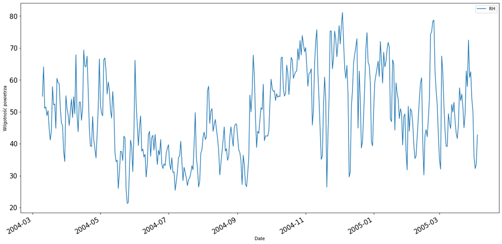

```python
plt.figure(figsize=(20,10))
airqualitytest.groupby('Date')['RH'].mean().plot(x = 'Date',
                                             y='RH',
                                             legend='auto',
                                             ylabel = "Wilgotność powietrza",
                                             fontsize =15)
```

```python
airqualitytest
```

|  | Date | Time | CO(GT) | PT08.S1(CO) | C6H6(GT) | PT08.S2(NMHC) | NOx(GT) | PT08.S3(NOx) | NO2(GT) | PT08.S4(NO2) | PT08.S5(O3) | T | RH | AH |
| --- | --- | --- | --- | --- | --- | --- | --- | --- | --- | --- | --- | --- | --- | --- |
| 0 | 2004-03-10 | 18:00:00 | 2.6 | 1360.00 | 11.881723 | 1045.50 | 166.0 | 1056.25 | 113.0 | 1692.00 | 1267.50 | 13.600 | 48.875001 | 0.757754 |
| 1 | 2004-03-10 | 19:00:00 | 2.0 | 1292.25 | 9.397165 | 954.75 | 103.0 | 1173.75 | 92.0 | 1558.75 | 972.25 | 13.300 | 47.700000 | 0.725487 |
| 2 | 2004-03-10 | 20:00:00 | 2.2 | 1402.00 | 8.997817 | 939.25 | 131.0 | 1140.00 | 114.0 | 1554.50 | 1074.00 | 11.900 | 53.975000 | 0.750239 |
| 3 | 2004-03-10 | 21:00:00 | 2.2 | 1375.50 | 9.228796 | 948.25 | 172.0 | 1092.00 | 122.0 | 1583.75 | 1203.25 | 11.000 | 60.000000 | 0.786713 |
| 4 | 2004-03-10 | 22:00:00 | 1.6 | 1272.25 | 6.518224 | 835.50 | 131.0 | 1205.00 | 116.0 | 1490.00 | 1110.00 | 11.150 | 59.575001 | 0.788794 |
| ... | ... | ... | ... | ... | ... | ... | ... | ... | ... | ... | ... | ... | ... | ... |
| 9352 | 2005-04-04 | 10:00:00 | 3.1 | 1314.25 | 13.529605 | 1101.25 | 471.7 | 538.50 | 189.8 | 1374.25 | 1728.50 | 21.850 | 29.250000 | 0.756824 |
| 9353 | 2005-04-04 | 11:00:00 | 2.4 | 1162.50 | 11.355157 | 1027.00 | 353.3 | 603.75 | 179.2 | 1263.50 | 1269.00 | 24.325 | 23.725000 | 0.711864 |
| 9354 | 2005-04-04 | 12:00:00 | 2.4 | 1142.00 | 12.374538 | 1062.50 | 293.0 | 603.25 | 174.7 | 1240.75 | 1092.00 | 26.900 | 18.350000 | 0.640649 |
| 9355 | 2005-04-04 | 13:00:00 | 2.1 | 1002.50 | 9.547187 | 960.50 | 234.5 | 701.50 | 155.7 | 1041.00 | 769.75 | 28.325 | 13.550000 | 0.513866 |
| 9356 | 2005-04-04 | 14:00:00 | 2.2 | 1070.75 | 11.932060 | 1047.25 | 265.2 | 654.00 | 167.7 | 1128.50 | 816.00 | 28.500 | 13.125000 | 0.502804 |

8991 rows × 14 columns

Wykrycie obserwacji odstających

```python
model = DBSCAN(eps= 0.8, min_samples=2).fit(airqualitytest.iloc[:,2:])
outliers_df = pd.DataFrame(airqualitytest.iloc[:,2:])
model.labels_
```

```
array([-1, -1, -1, ..., -1, -1, -1], dtype=int64)
```

```python
print(Counter(model.labels_))
print(outliers_df[model.labels_!=-1])
```

```
Counter({-1: 8991})
Empty DataFrame
Columns: [CO(GT), PT08.S1(CO), C6H6(GT), PT08.S2(NMHC), NOx(GT), PT08.S3(NOx), NO2(GT), PT08.S4(NO2), PT08.S5(O3), T, RH, AH]
Index: []
```

```python
airqualityKNN.corr()
```

|  | CO(GT) | PT08.S1(CO) | C6H6(GT) | PT08.S2(NMHC) | NOx(GT) | PT08.S3(NOx) | NO2(GT) | PT08.S4(NO2) | PT08.S5(O3) | T | RH | AH |
| --- | --- | --- | --- | --- | --- | --- | --- | --- | --- | --- | --- | --- |
| CO(GT) | 1.000000 | 0.879017 | 0.928300 | 0.911359 | 0.808834 | -0.708818 | 0.705842 | 0.633083 | 0.855327 | 0.034947 | 0.019250 | 0.038451 |
| PT08.S1(CO) | 0.879017 | 1.000000 | 0.884325 | 0.893509 | 0.715971 | -0.773736 | 0.654891 | 0.685937 | 0.900249 | 0.051695 | 0.110036 | 0.134160 |
| C6H6(GT) | 0.928300 | 0.884325 | 1.000000 | 0.982270 | 0.734743 | -0.737891 | 0.637430 | 0.767299 | 0.866957 | 0.201608 | -0.065741 | 0.165667 |
| PT08.S2(NMHC) | 0.911359 | 0.893509 | 0.982270 | 1.000000 | 0.719671 | -0.798378 | 0.668096 | 0.778889 | 0.881592 | 0.243992 | -0.094405 | 0.184747 |
| NOx(GT) | 0.808834 | 0.715971 | 0.734743 | 0.719671 | 1.000000 | -0.656175 | 0.770089 | 0.277730 | 0.785781 | -0.222210 | 0.168789 | -0.136933 |
| PT08.S3(NOx) | -0.708818 | -0.773736 | -0.737891 | -0.798378 | -0.656175 | 1.000000 | -0.651475 | -0.541961 | -0.798449 | -0.148697 | -0.052076 | -0.230356 |
| NO2(GT) | 0.705842 | 0.654891 | 0.637430 | 0.668096 | 0.770089 | -0.651475 | 1.000000 | 0.201871 | 0.715667 | -0.156009 | -0.114823 | -0.318769 |
| PT08.S4(NO2) | 0.633083 | 0.685937 | 0.767299 | 0.778889 | 0.277730 | -0.541961 | 0.201871 | 1.000000 | 0.594818 | 0.559899 | -0.035880 | 0.626515 |
| PT08.S5(O3) | 0.855327 | 0.900249 | 0.866957 | 0.881592 | 0.785781 | -0.798449 | 0.715667 | 0.594818 | 1.000000 | -0.023785 | 0.121591 | 0.070014 |
| T | 0.034947 | 0.051695 | 0.201608 | 0.243992 | -0.222210 | -0.148697 | -0.156009 | 0.559899 | -0.023785 | 1.000000 | -0.582478 | 0.655065 |
| RH | 0.019250 | 0.110036 | -0.065741 | -0.094405 | 0.168789 | -0.052076 | -0.114823 | -0.035880 | 0.121591 | -0.582478 | 1.000000 | 0.164924 |
| AH | 0.038451 | 0.134160 | 0.165667 | 0.184747 | -0.136933 | -0.230356 | -0.318769 | 0.626515 | 0.070014 | 0.655065 | 0.164924 | 1.000000 |

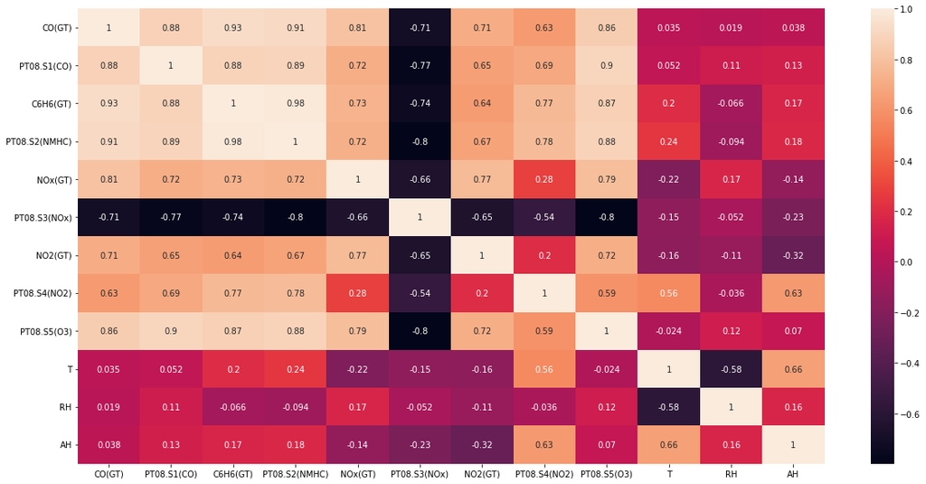

```python
plt.figure(figsize=(20,10))
sns.heatmap(airqualityKNN.corr(), annot=True)
```

Stężenie pierwiastków w powietrzą są mocno ze sobą skorelowane. Wszystkie zmienne zawiaerające informacje o pierwiastach w powietrzu prócz 'PT08.S3(NOx)' są ze sobą dodatnio skorelowane. Tylko z cechą 'PT08.S3(NOx)' reszta jest skorelowana ujemnie.

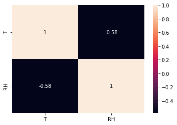

```python
sns.heatmap(airqualityKNN[['T','RH']].corr(), annot=True)
```

Gdy Temperatura wzrast to wilgotność powietrza"RH' maleje